# EFFDIS Effort Estimation

Doug Beare with assistance from the ICCAT Secretariat

03/06/2015

# SHORT-TERM CONTRACT: A MODELING APPROACH TO ESTIMATE OVERALL ATLANTIC FISHING EFFORT BY TIME-AREA STRATA (EFFDIS)

### Objectives

- Develop a robust statistical modeling approach to estimate overall Atlantic fishing effort stratified by flag/fleet, gear, area (5ºx5º degree square grid), year and month (starting in 1950).
- Update the current EFFDIS estimations for longline gear (1950 to 2014) using the new approach, and then develop estimation procedures for baitboat and purse-seine with the appropriate effort units.

# The SGECO Working group made a series of recommendations for improving EFFDIS, ie.to:

- Consider seasonal and spatial patterns and their interactions
- Understand how information from species composition can best be used in this context
- Combine bait boat and purse-seine estimates with long-line
- Estimate uncertainty/variance
- Exploit other relevant information where available, e.g. VMS data

# Overall workplan

- Obtain all the relevant data and review the current methods for EFFDIS estimation
- Write documented R code to mimic the current procedure
- Develop ‘strawman’ methodologies for estimating fishing effort for a single fleet/flag country
- Once a method is approved for one fleet the Contractor will then adapt it to other fleets to produce global estimates
- Use an online SQL relational database linked to R-scripts

# Detailed short-term workplan

- Explore data for non-random, non-representative sampling (data catalogue)
- Investigate the relationship (sum of products) between Task 1, which focuses on the total catches of 9 major tuna & tuna-like species (Albacore, Bluefin, Yellowfin, Bigeye, Skipjack, Swordfish, Blue Marlin, White Marlin, Sailfish), and Task 2 data which is more detailed containing more detailed information on location, season, etc.
- Develop most appropriate multi-variate models (e.g. GLMs, GAMs) for interpoplation
- Estimate variance/bias with jack-knife
- Test predictions using cross-validation methodology

# Exploring data for non-random, non-representative sampling (data catalogue)

### Sampling by year and month - Chinese Taipei

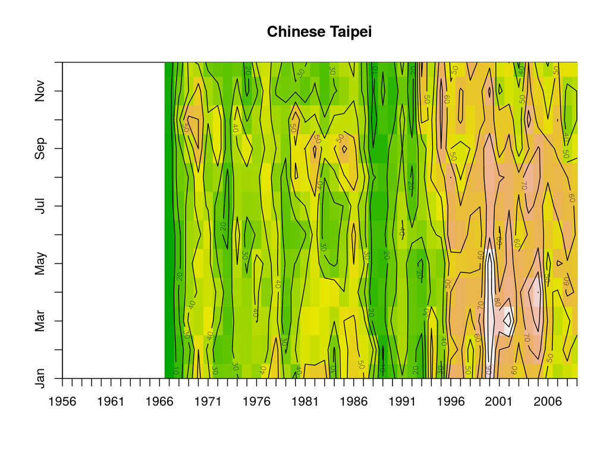

# Sampling by year and month - Japan

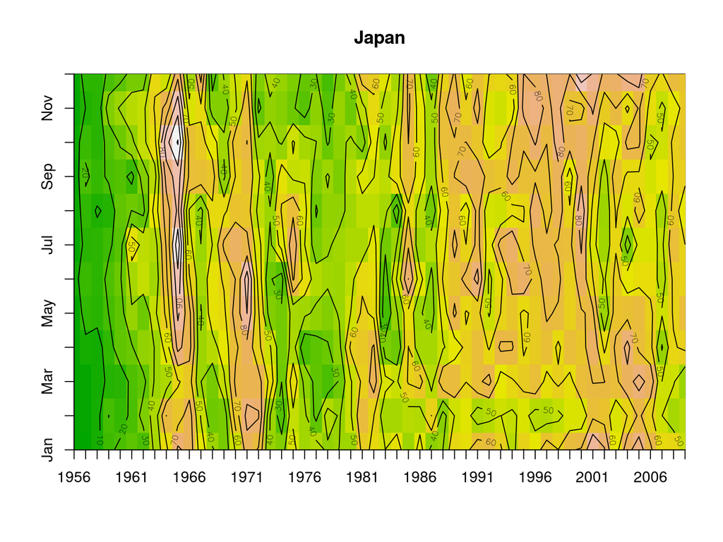

# Sampling in space by year - Chinese Taipei

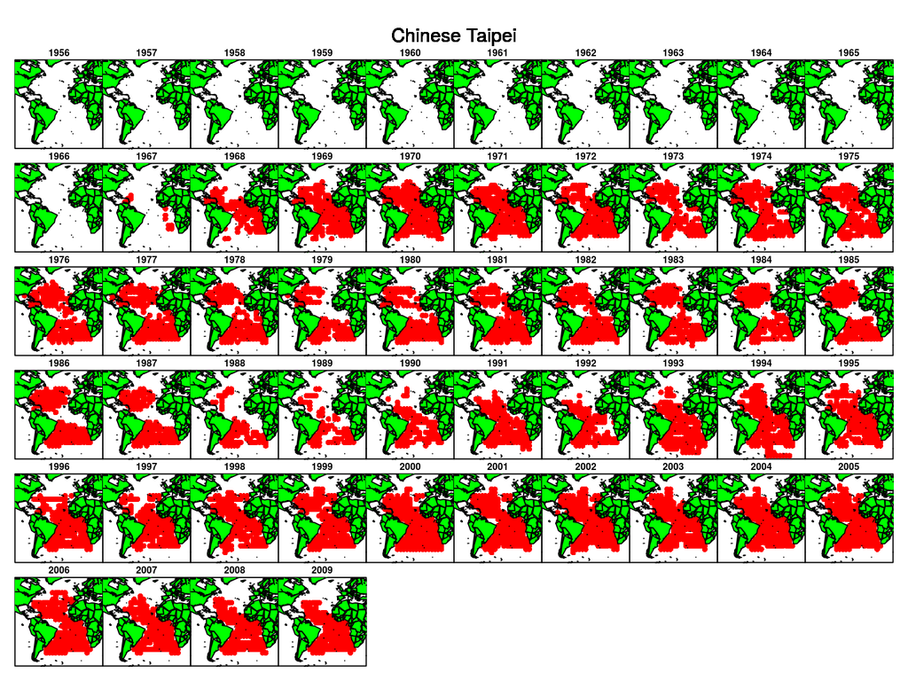